# Dissertação Marco Matta

Marco Matta e [Henrique Laureano](https://henriquelaureano.github.io/)

Last modification on* 2022-06-04 11:25:25

# Idade

```
   Min. 1st Qu.  Median    Mean 3rd Qu.    Max.      SD     Var
23.5890 33.4521 39.2164 38.2887 42.6555 52.1479  6.8922 47.5029
```

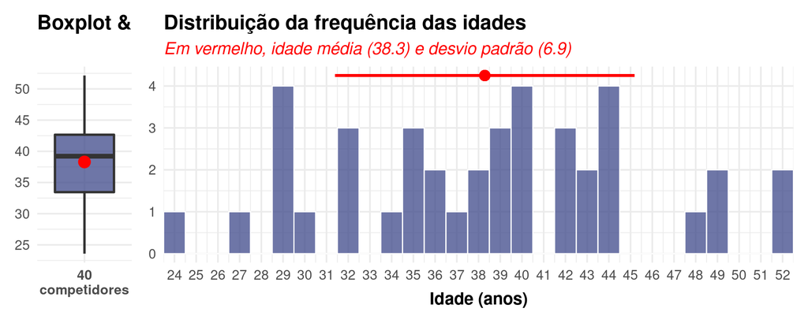

# Tempo de prova

```
     Min.   1st Qu.    Median      Mean   3rd Qu.      Max.        SD       Var
 312.1100  446.9600  482.3350  500.0412  567.6175  668.4500   90.8872 8260.4864
```

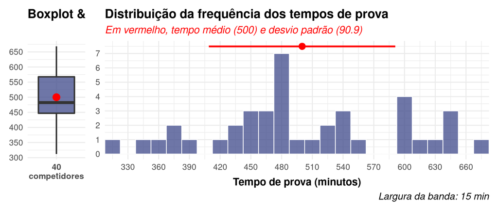

# Cruzamento

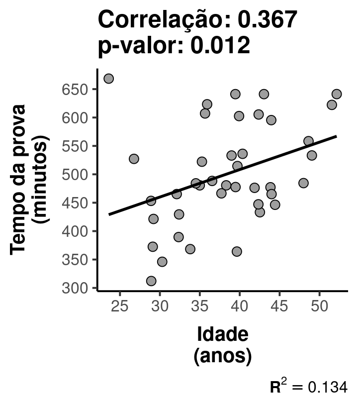

# Pré vs. Pós

> **Peso (Kg)**

> Medidas descritivas (mínimo, 1o quartil, mediana, média, 3o quartil, máximo, desvio padrão (SD, em inglês), e variância).

Medidas descritivas

| Prova | Min. | 1st Qu. | Median | Mean | 3rd Qu. | Max. | SD | Var |
| --- | --- | --- | --- | --- | --- | --- | --- | --- |
| Pré | 58.3 | 69.075 | 75.55 | 75.552 | 79.5 | 100.8 | 8.844 | 78.219 |
| Pós | 58.5 | 67.550 | 73.85 | 73.430 | 76.5 | 98.6 | 8.443 | 71.284 |
| Pré - Pós | -0.5 | 1.300 | 1.95 | 2.122 | 3.0 | 5.5 | 1.278 | 1.634 |

> As medidas são normais?

```
    Shapiro-Wilk normality test

data:  dat$"Peso (Kg).Pré"
W = 0.9577, p-value = 0.1397
```

```
    Shapiro-Wilk normality test

data:  dat$"Peso (Kg).Pós"
W = 0.95198, p-value = 0.0887
```

> São. Não rejeitamos a hipótese de normalidade (p-valor > 0.05) em nenhum cenário.

> A diferença é estatísticamente significativa?

```
    Paired t-test

data:  dat$"Peso (Kg).Pré" and dat$"Peso (Kg).Pós"
t = 10.501, df = 39, p-value = 6.291e-13
alternative hypothesis: true mean difference is not equal to 0
95 percent confidence interval:
 1.713674 2.531326
sample estimates:
mean difference
         2.1225
```

> Sim (p-valor 0.0000000000006291 < 0.05).

> **Gordura corporal (%)**

Medidas descritivas

| Prova | Min. | 1st Qu. | Median | Mean | 3rd Qu. | Max. | SD | Var |
| --- | --- | --- | --- | --- | --- | --- | --- | --- |
| Pré | 6.8 | 9.600 | 10.35 | 10.883 | 11.900 | 17.3 | 2.171 | 4.715 |
| Pós | 4.3 | 8.775 | 9.65 | 9.705 | 11.125 | 12.5 | 1.811 | 3.280 |
| Pré - Pós | -2.3 | -0.100 | 1.00 | 1.178 | 2.700 | 4.8 | 1.802 | 3.247 |

> Testando a normalidade.

```
    Shapiro-Wilk normality test

data:  dat$"B FAT %.Pré"
W = 0.92678, p-value = 0.01266
```

```
    Shapiro-Wilk normality test

data:  dat$"B FAT %.Pós"
W = 0.95269, p-value = 0.09389
```

```
    Paired t-test

data:  dat$"B FAT %.Pré" and dat$"B FAT %.Pós"
t = 4.1329, df = 39, p-value = 0.0001837
alternative hypothesis: true mean difference is not equal to 0
95 percent confidence interval:
 0.6012179 1.7537821
sample estimates:
mean difference
         1.1775
```

> **Gordura corporal (Kg)**

Medidas descritivas

| Prova | Min. | 1st Qu. | Median | Mean | 3rd Qu. | Max. | SD | Var |
| --- | --- | --- | --- | --- | --- | --- | --- | --- |
| Pré | 4.2 | 6.7 | 8.4 | 8.295 | 9.300 | 13.2 | 2.082 | 4.335 |
| Pós | 2.6 | 6.1 | 6.8 | 7.175 | 8.425 | 11.4 | 1.832 | 3.356 |
| Pré - Pós | -1.5 | 0.2 | 0.9 | 1.120 | 2.175 | 4.4 | 1.448 | 2.097 |

> Testando a normalidade.

```
    Shapiro-Wilk normality test

data:  dat$"B FAT (Kg).Pré"
W = 0.95447, p-value = 0.1081
```

```
    Shapiro-Wilk normality test

data:  dat$"B FAT (Kg).Pós"
W = 0.98159, p-value = 0.7483
```

> Teste-*t* pareado.

```
    Paired t-test

data:  dat$"B FAT (Kg).Pré" and dat$"B FAT (Kg).Pós"
t = 4.8915, df = 39, p-value = 1.762e-05
alternative hypothesis: true mean difference is not equal to 0
95 percent confidence interval:
 0.6568716 1.5831284
sample estimates:
mean difference
           1.12
```

> **Lean (Kg)**

Medidas descritivas

| Prova | Min. | 1st Qu. | Median | Mean | 3rd Qu. | Max. | SD | Var |
| --- | --- | --- | --- | --- | --- | --- | --- | --- |
| Pré | 51.8 | 62.175 | 67.05 | 67.525 | 71.475 | 89.0 | 7.828 | 61.271 |
| Pós | 52.8 | 61.350 | 65.20 | 65.952 | 69.150 | 87.2 | 7.136 | 50.923 |
| Pré - Pós | -2.3 | -0.325 | 1.30 | 1.572 | 2.450 | 8.6 | 2.319 | 5.380 |

> Testando a normalidade.

```
    Shapiro-Wilk normality test

data:  dat$"Lean (Kg).Pré"
W = 0.9424, p-value = 0.0417
```

```
    Shapiro-Wilk normality test

data:  dat$"Lean (Kg).Pós"
W = 0.92221, p-value = 0.009044
```

> Teste de Wilcoxon.

```
    Wilcoxon signed rank test with continuity correction

data:  dat$"Lean (Kg).Pré" and dat$"Lean (Kg).Pós"
V = 662, p-value = 0.0001511
alternative hypothesis: true location shift is not equal to 0
```

> A seguir temos as médias das diferenças, p-valores e o perfil/variação de cada um dos 40 competidores em cada um das quatro medidas acima testadas.

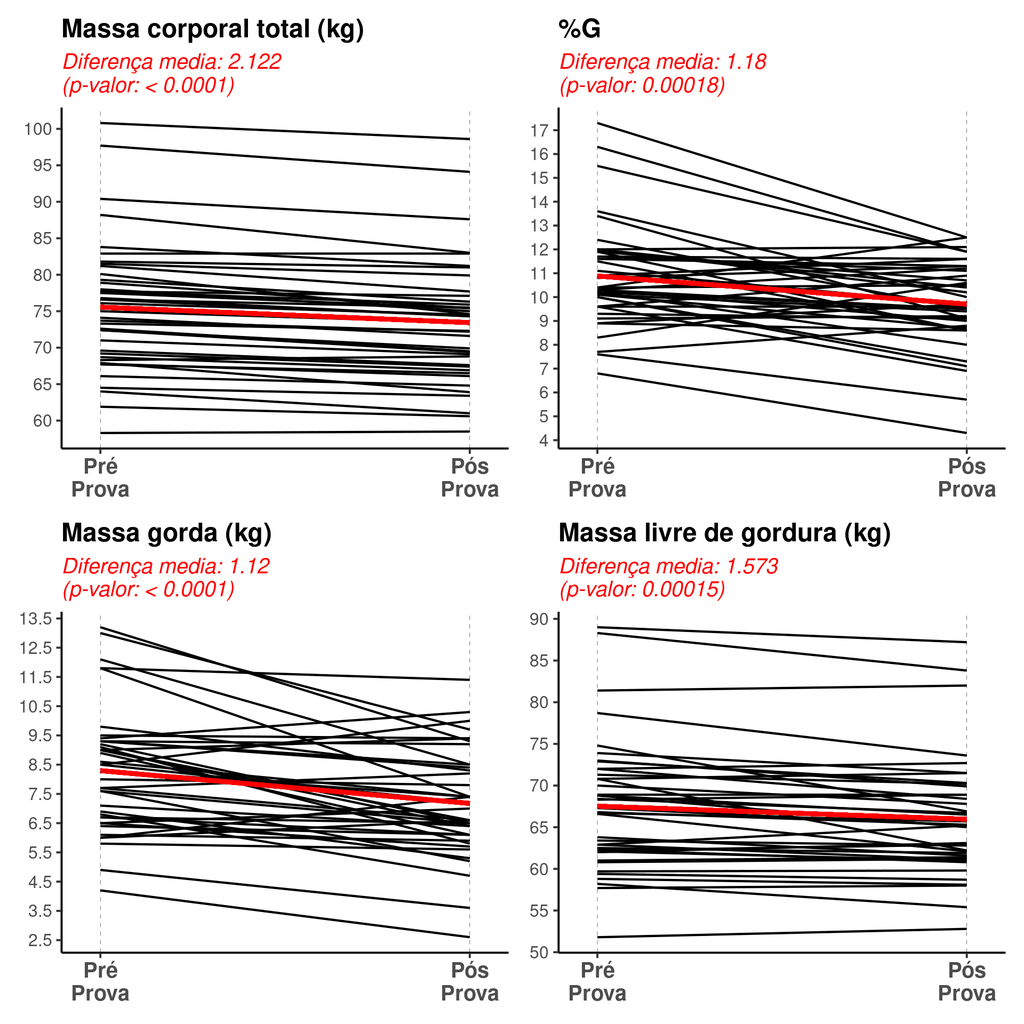

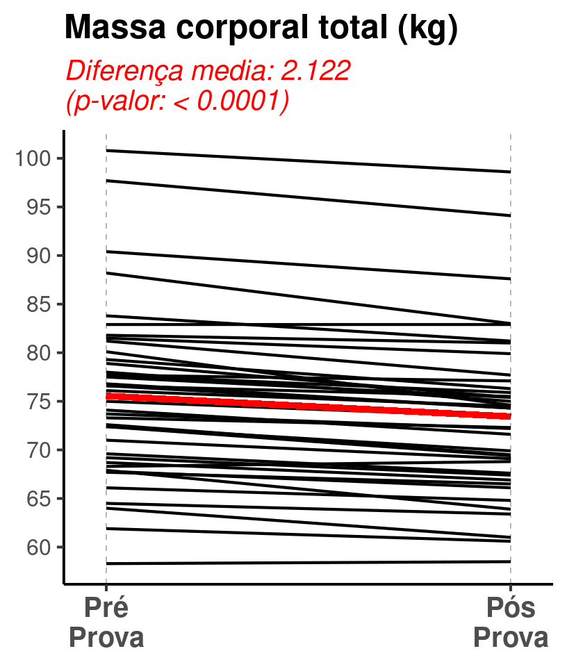

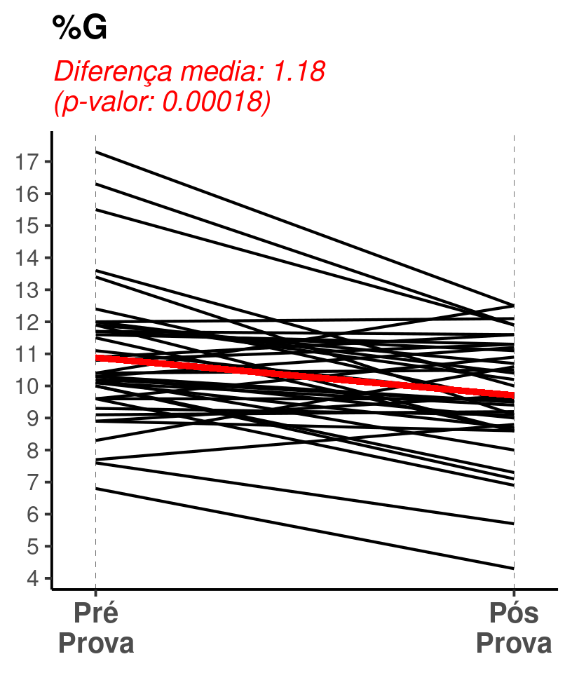

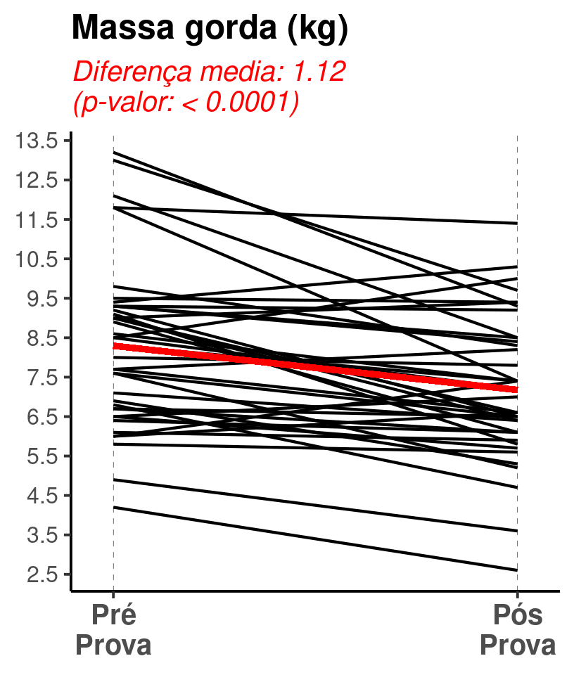

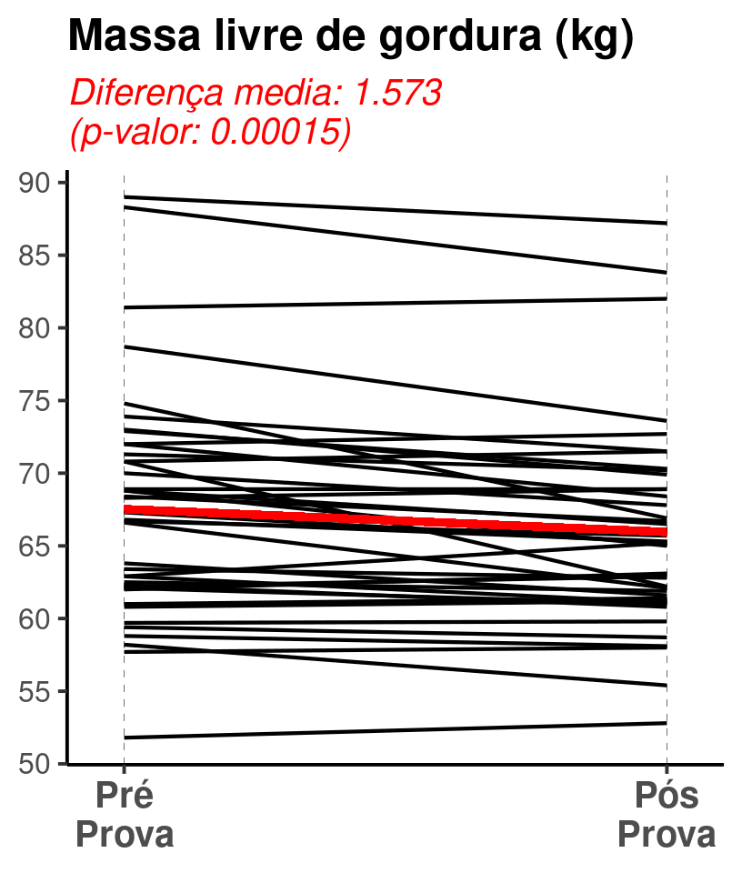

> E as médias testadas acima.

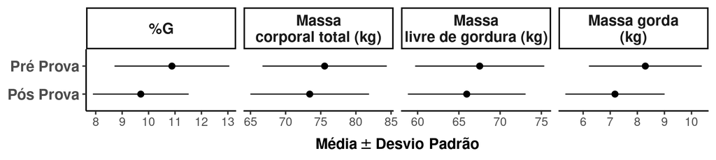

# Na+ (mmol/L)

Medidas descritivas

| Prova | Min. | 1st Qu. | Median | Mean | 3rd Qu. | Max. | SD | Var |
| --- | --- | --- | --- | --- | --- | --- | --- | --- |
| Pré | 138 | 142 | 143 | 142.775 | 144.00 | 147 | 2.082 | 4.333 |
| Pós | 139 | 141 | 144 | 143.775 | 145.25 | 151 | 2.750 | 7.563 |
| Pré - Pós | -8 | -3 | -1 | -1.000 | 2.00 | 6 | 3.389 | 11.487 |

```
    Shapiro-Wilk normality test

data:  dat$"Na+ (mmol/L).Pré"
W = 0.96177, p-value = 0.1925
```

```
    Shapiro-Wilk normality test

data:  dat$"Na+ (mmol/L).Pós"
W = 0.96415, p-value = 0.2317
```

```
    Paired t-test

data:  dat$"Na+ (mmol/L).Pré" and dat$"Na+ (mmol/L).Pós"
t = -1.8661, df = 39, p-value = 0.06957
alternative hypothesis: true mean difference is not equal to 0
95 percent confidence interval:
 -2.08394247  0.08394247
sample estimates:
mean difference
             -1
```

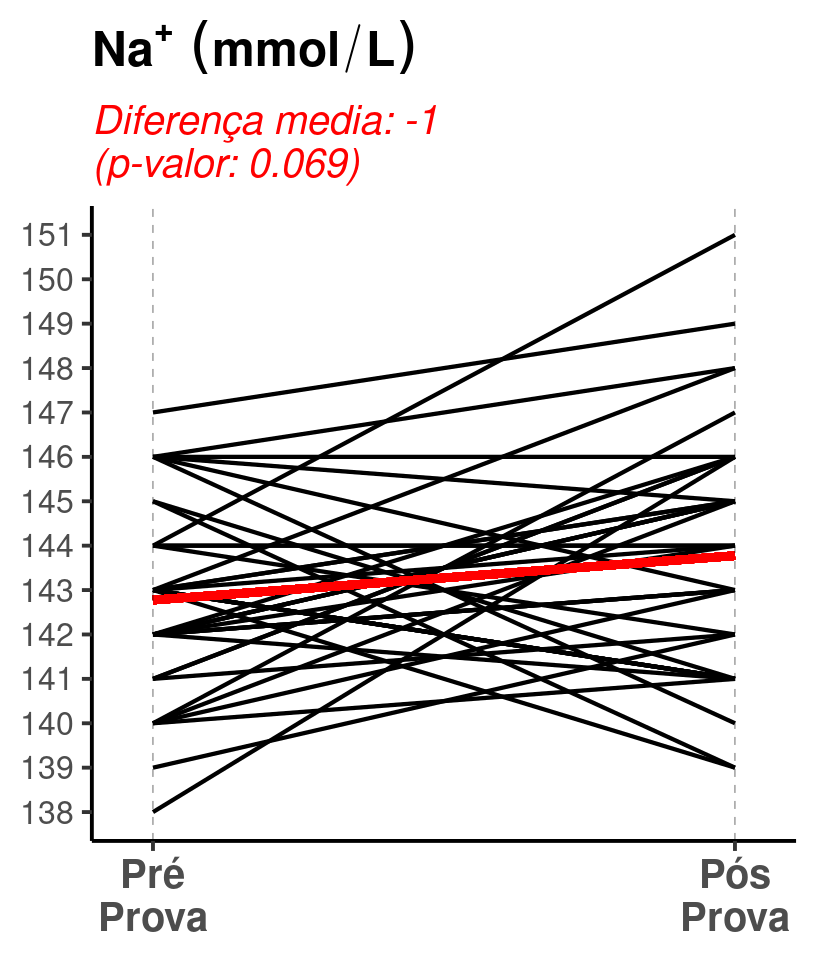

# K+ (mmol/L)

Medidas descritivas

| Prova | Min. | 1st Qu. | Median | Mean | 3rd Qu. | Max. | SD | Var |
| --- | --- | --- | --- | --- | --- | --- | --- | --- |
| Pré | 4.1 | 4.675 | 5.00 | 5.076 | 5.4 | 7.42 | 0.661 | 0.437 |
| Pós | 3.5 | 3.900 | 4.20 | 4.230 | 4.5 | 5.20 | 0.376 | 0.141 |
| Pré - Pós | -0.8 | 0.500 | 0.75 | 0.846 | 1.2 | 3.42 | 0.725 | 0.526 |

```
    Shapiro-Wilk normality test

data:  dat$"K+ (mmol/L).Pré"
W = 0.90129, p-value = 0.002084
```

```
    Shapiro-Wilk normality test

data:  dat$"K+ (mmol/L).Pós"
W = 0.9722, p-value = 0.4215
```

```
    Paired t-test

data:  dat$"K+ (mmol/L).Pré" and dat$"K+ (mmol/L).Pós"
t = 7.3717, df = 39, p-value = 6.652e-09
alternative hypothesis: true mean difference is not equal to 0
95 percent confidence interval:
 0.6135081 1.0774919
sample estimates:
mean difference
         0.8455
```

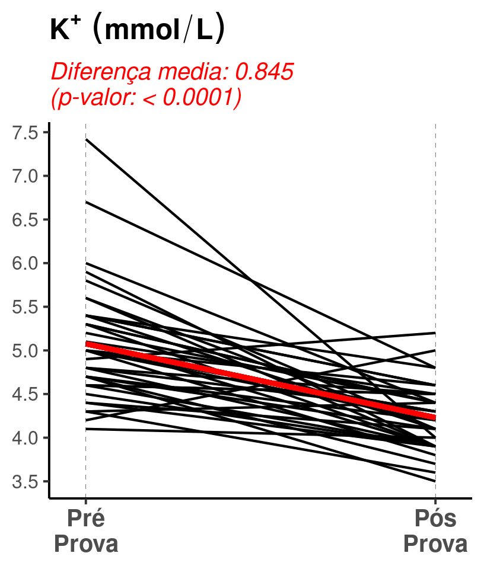

# Ca++ (mmol/L)

Medidas descritivas

| Prova | Min. | 1st Qu. | Median | Mean | 3rd Qu. | Max. | SD | Var |
| --- | --- | --- | --- | --- | --- | --- | --- | --- |
| Pré | 1.14 | 1.19 | 1.22 | 1.231 | 1.252 | 1.41 | 0.063 | 0.004 |
| Pós | 1.09 | 1.16 | 1.18 | 1.184 | 1.205 | 1.30 | 0.043 | 0.002 |
| Pré - Pós | -0.08 | 0.00 | 0.05 | 0.047 | 0.090 | 0.25 | 0.075 | 0.006 |

```
    Shapiro-Wilk normality test

data:  dat$"Ca++ (mmol/L).Pré"
W = 0.88567, p-value = 0.0007513
```

```
    Shapiro-Wilk normality test

data:  dat$"Ca++ (mmol/L).Pós"
W = 0.98579, p-value = 0.8877
```

```
    Paired t-test

data:  dat$"Ca++ (mmol/L).Pré" and dat$"Ca++ (mmol/L).Pós"
t = 3.92, df = 39, p-value = 0.0003476
alternative hypothesis: true mean difference is not equal to 0
95 percent confidence interval:
 0.02262741 0.07087259
sample estimates:
mean difference
        0.04675
```

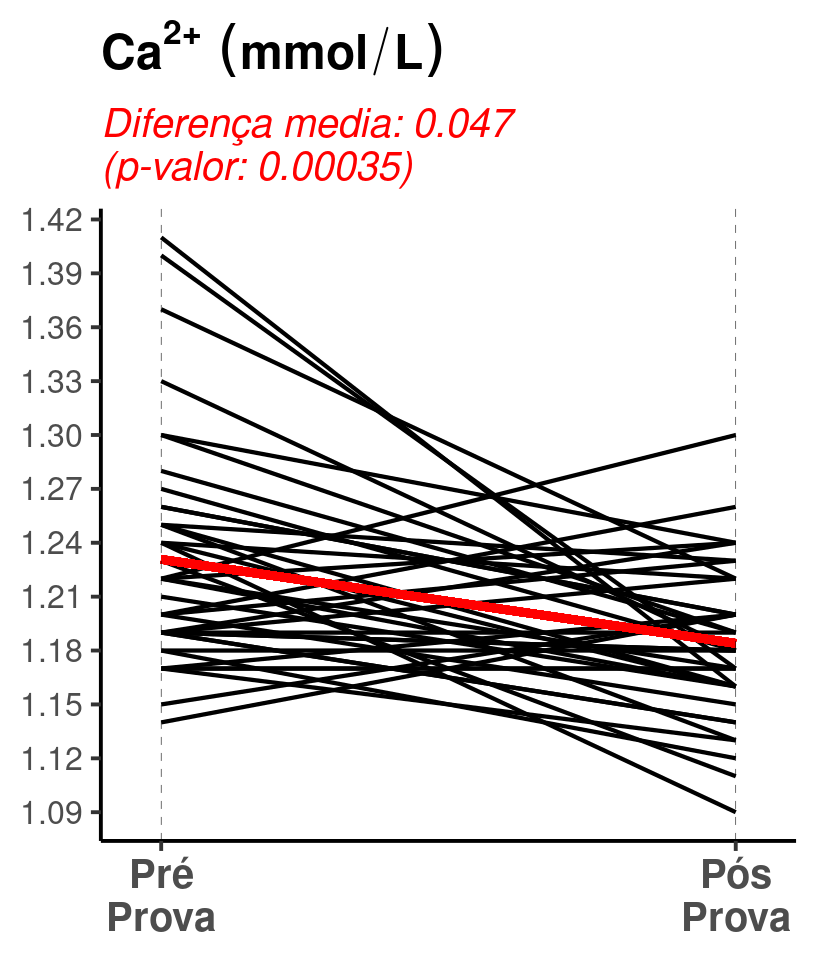

# Glu (mg/dL)

Medidas descritivas

| Prova | Min. | 1st Qu. | Median | Mean | 3rd Qu. | Max. | SD | Var |
| --- | --- | --- | --- | --- | --- | --- | --- | --- |
| Pré | 78 | 85.50 | 94 | 95.025 | 102.25 | 124 | 11.759 | 138.281 |
| Pós | 55 | 76.75 | 87 | 92.100 | 111.00 | 150 | 20.910 | 437.221 |
| Pré - Pós | -41 | -14.25 | 6 | 2.925 | 19.00 | 46 | 22.319 | 498.122 |

```
    Shapiro-Wilk normality test

data:  dat$"Glu (mg/dL).Pré"
W = 0.95288, p-value = 0.09532
```

```
    Shapiro-Wilk normality test

data:  dat$"Glu (mg/dL).Pós"
W = 0.94768, p-value = 0.06311
```

```
    Paired t-test

data:  dat$"Glu (mg/dL).Pré" and dat$"Glu (mg/dL).Pós"
t = 0.82887, df = 39, p-value = 0.4122
alternative hypothesis: true mean difference is not equal to 0
95 percent confidence interval:
 -4.212853 10.062853
sample estimates:
mean difference
          2.925
```

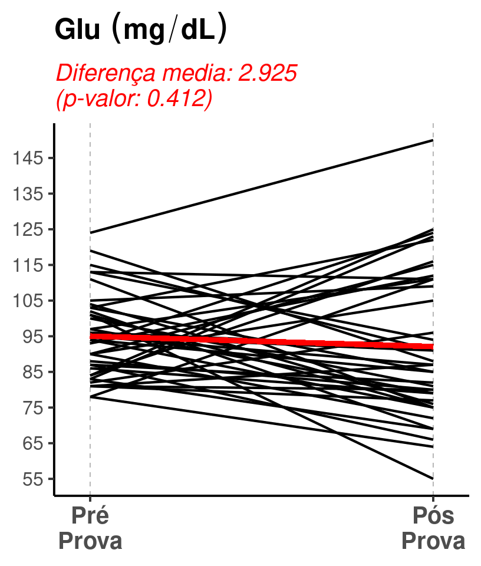

# Hct %

Medidas descritivas

| Prova | Min. | 1st Qu. | Median | Mean | 3rd Qu. | Max. | SD | Var |
| --- | --- | --- | --- | --- | --- | --- | --- | --- |
| Pré | 40 | 44.00 | 45.0 | 45.725 | 47.25 | 53 | 3.130 | 9.794 |
| Pós | 38 | 44.00 | 46.5 | 46.650 | 49.00 | 55 | 3.302 | 10.900 |
| Pré - Pós | -11 | -3.25 | -1.0 | -0.925 | 2.00 | 9 | 4.015 | 16.122 |

```
    Shapiro-Wilk normality test

data:  dat$"Hct %.Pré"
W = 0.96533, p-value = 0.2537
```

```
    Shapiro-Wilk normality test

data:  dat$"Hct %.Pós"
W = 0.97557, p-value = 0.5294
```

```
    Paired t-test

data:  dat$"Hct %.Pré" and dat$"Hct %.Pós"
t = -1.457, df = 39, p-value = 0.1531
alternative hypothesis: true mean difference is not equal to 0
95 percent confidence interval:
 -2.2091473  0.3591473
sample estimates:
mean difference
         -0.925
```

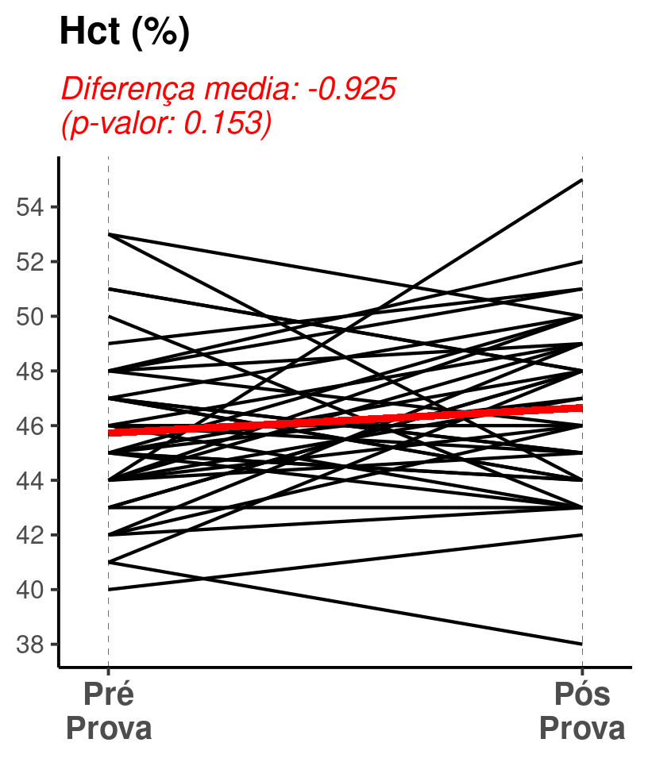

# Médias

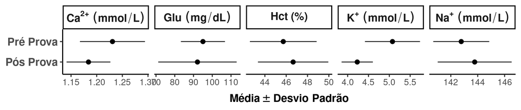

# Tempo de prova vs. Diferenças

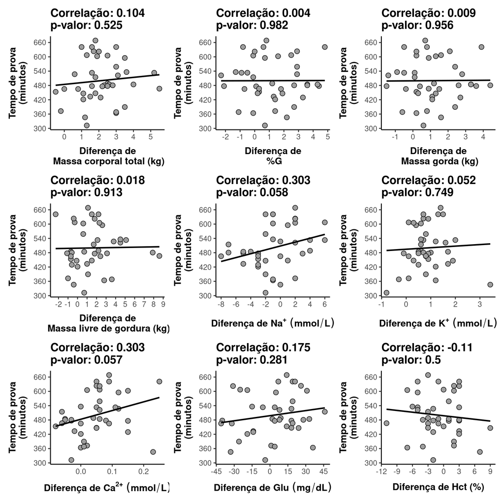

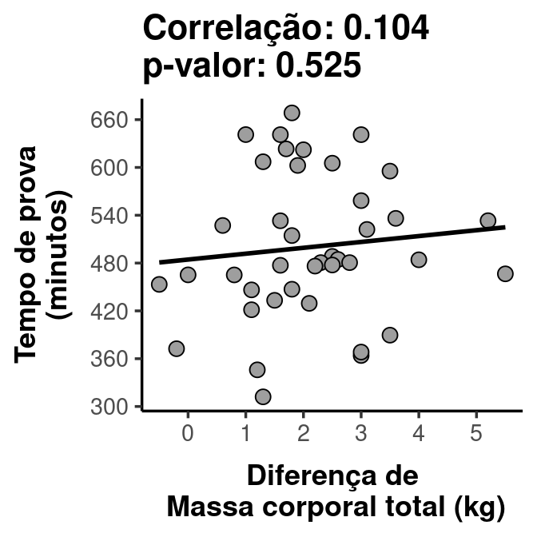

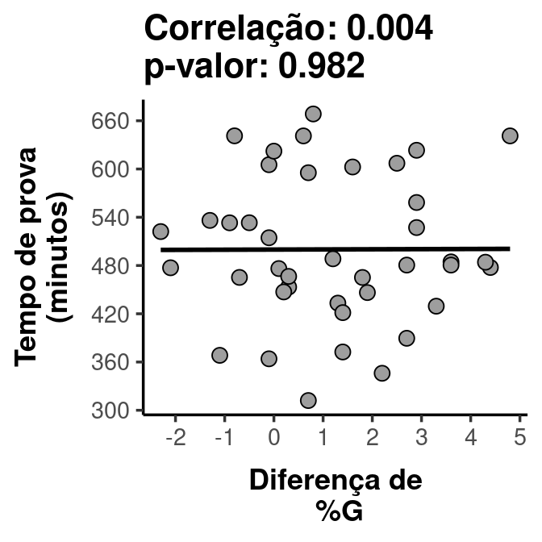

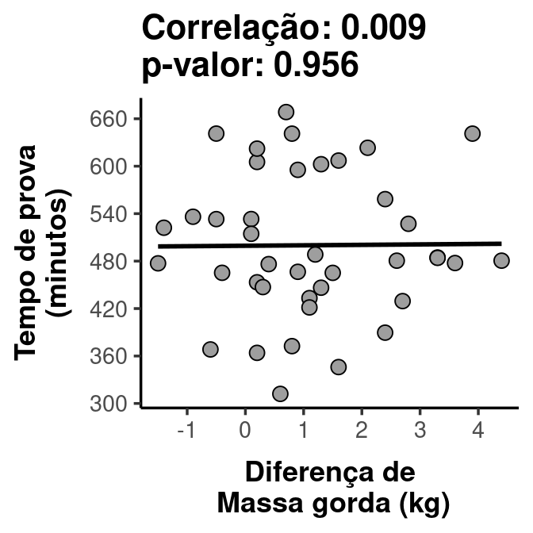

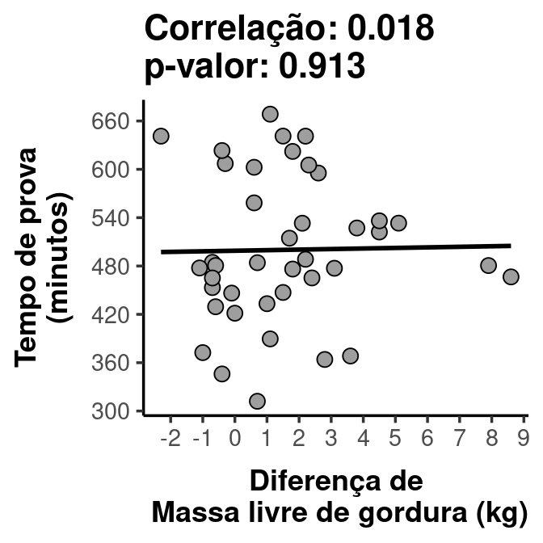

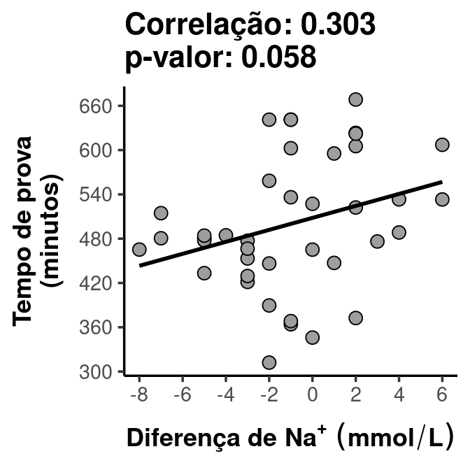

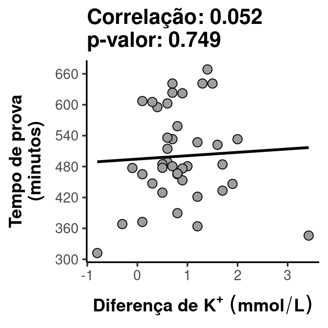

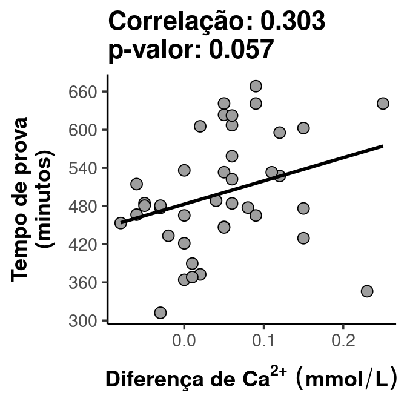

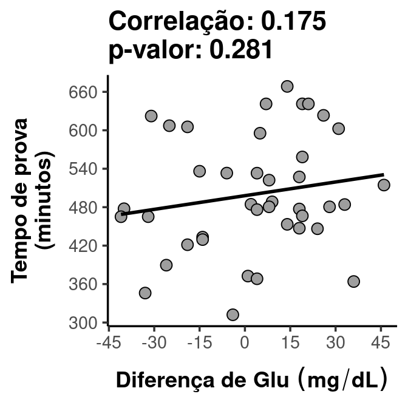

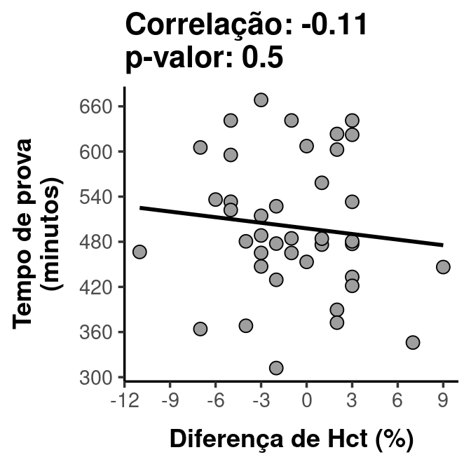

# Extra

```
pcvar
Maior Menor
   20    20
```

> 20 competidores abaixo da mediana (482.335), e 20 acima da mediana.

> Nos 20 competidores abaixo da mediana, para cada uma das variáveis, média e desvio padrão pré e pós- competição.

```
# A tibble: 18 × 4
   prova     name            mean      sd
   <chr>     <chr>          <dbl>   <dbl>
 1 Pós Prova B FAT (Kg)      6.98  1.86
 2 Pré Prova B FAT (Kg)      8.14  2.10
 3 Pós Prova B FAT %         9.40  1.76
 4 Pré Prova B FAT %        10.6   1.97
 5 Pós Prova Ca++ (mmol/L)   1.20  0.0365
 6 Pré Prova Ca++ (mmol/L)   1.22  0.0675
 7 Pós Prova Glu (mg/dL)    98.2  20.9
 8 Pré Prova Glu (mg/dL)    95.8  13.1
 9 Pós Prova Hct %          46.6   3.56
10 Pré Prova Hct %          46.4   3.30
11 Pós Prova K+ (mmol/L)     4.32  0.403
12 Pré Prova K+ (mmol/L)     5.10  0.794
13 Pós Prova Lean (Kg)      66.5   8.25
14 Pré Prova Lean (Kg)      67.9   8.69
15 Pós Prova Na+ (mmol/L)  145.    1.98
16 Pré Prova Na+ (mmol/L)  142.    2.42
17 Pós Prova Peso (Kg)      73.7   9.48
18 Pré Prova Peso (Kg)      75.5   9.84
```

> E p-valores comparando o pré com pós.

```
# A tibble: 9 × 2
  variavel         pvalor
  <chr>             <dbl>
1 Peso (Kg)     0.0000113
2 B FAT %       0.00401
3 B FAT (Kg)    0.00183
4 Lean (Kg)     0.0269
5 Na+ (mmol/L)  0.00141
6 K+ (mmol/L)   0.000968
7 Ca++ (mmol/L) 0.144
8 Glu (mg/dL)   0.649
9 Hct %         0.775
```

> Nos 20 competidores acima da mediana, para cada uma das variáveis, média e desvio padrão pré e pós- competição.

```
# A tibble: 18 × 4
   prova     name            mean      sd
   <chr>     <chr>          <dbl>   <dbl>
 1 Pós Prova B FAT (Kg)      7.38  1.83
 2 Pré Prova B FAT (Kg)      8.46  2.10
 3 Pós Prova B FAT %        10.0   1.85
 4 Pré Prova B FAT %        11.1   2.37
 5 Pós Prova Ca++ (mmol/L)   1.17  0.0447
 6 Pré Prova Ca++ (mmol/L)   1.24  0.0602
 7 Pós Prova Glu (mg/dL)    86.0  19.5
 8 Pré Prova Glu (mg/dL)    94.2  10.5
 9 Pós Prova Hct %          46.6   3.12
10 Pré Prova Hct %          45.1   2.90
11 Pós Prova K+ (mmol/L)     4.14  0.332
12 Pré Prova K+ (mmol/L)     5.05  0.514
13 Pós Prova Lean (Kg)      65.4   5.99
14 Pré Prova Lean (Kg)      67.1   7.06
15 Pós Prova Na+ (mmol/L)  143.    3.03
16 Pré Prova Na+ (mmol/L)  143.    1.70
17 Pós Prova Peso (Kg)      73.2   7.50
18 Pré Prova Peso (Kg)      75.6   7.98
```

> p-valores comparando pré com pós.

```
# A tibble: 9 × 2
  variavel             pvalor
  <chr>                 <dbl>
1 Peso (Kg)     0.00000000879
2 B FAT %       0.0183
3 B FAT (Kg)    0.00448
4 Lean (Kg)     0.000789
5 Na+ (mmol/L)  0.654
6 K+ (mmol/L)   0.000000219
7 Ca++ (mmol/L) 0.000316
8 Glu (mg/dL)   0.0789
9 Hct %         0.0493
```

# Referência

> A análise estatística foi realizada no ambiente de computação estatística `R` (R Core Team, 2022). Para a descrição das variáveis/características mensuradas, diversas medidas resumo foram obtidas, como o cálculo dos principais quantis, médias, valores extremos, desvios padrão, e correlação de *Pearson* (Pearson, 1895). Além disso, gráficos de dispersão, caixa (*boxplots*), barra, e de linha, foram construídos. Como várias medidas são do tipo *follow-up* (antes/depois, pré/pós), testes de normalidade (*Shapiro-Wilks* (Royston 1982)) e testes de comparação de médias (Teste-*t* para amostras pareadas/Teste de *Wilcoxon signed rank* (Gosset, 1908; Martin, 1995; Fay & Proschan, 2010; Bauer, 1972; Hollander & Wolfe, 1999) foram performados. Os principais pacotes `R` utilizados foram o {`dplyr`} (Wickham et al., 2021), {`lubridate`} (Grolemund & Wickham, 2011), {`stringr`} (Wickham, 2019), {`ggplot2`} (Wickham, 2016), {`patckwork`} (Pedersen, 2020), {`rlang`} (Henry & Wickham, 2022), e {`tidyr`} (Wickham & Girlich, 2022).

> R Core Team (2022). R: A language and environment for statistical computing. R Foundation for Statistical Computing, Vienna, Austria. URL https://www.R-project.org/

> Pearson, K. (1895) Notes on regression and inheritance in the case of two parents. Proceedings of the Royal Society of London. 58: 240–242

> Royston, P. (1982). An extension of Shapiro and Wilk’s W test for normality to large samples. Applied Statistics, 31: 115-124. doi: 10.2307/2347973 (URL: https://doi.org/10.2307/2347973)

> Gosset, W. S. (1908). The probable error of a mean. Biometrika. 6 (1): 1–25. doi:10.1093/biomet/6.1.1

> Martin, B. (1995). An Introduction to Medical Statistics. Oxford University Press

> Fay, M. P., Proschan, M. A. (2010). Wilcoxon–Mann–Whitney or t-test? On assumptions for hypothesis tests and multiple interpretations of decision rules. Statistics Surveys. 4: 1–39

> Bauer, D. F. (1972). Constructing confidence sets using rank statistics. Journal of the American Statistical Association 67: 687-690. doi: 10.1080/01621459.1972.10481279 (URL: https://doi.org/10.1080/01621459.1972.10481279)

> Hollander, M., Wolfe, D. A. (1999). Nonparametric Statistical Methods. New York: John Wiley & Sons. 2nd ed

> Wickham, H., François, R., Henry, L., Müller, K. (2021). dplyr: A Grammar of Data Manipulation. R package version 1.0.7. https://CRAN.R-project.org/package=dplyr

> Grolemund, G., Wickham, H. (2011). Dates and Times Made Easy wih lubridate. Journal of Statistical Software, 40(3), 1-25. URL https://www.jstatsoft.org/v40/i03/

> Wickham, H. (2019). stringr: Simple, Consistent Wrappers for Common String Operations. R package version 1.4.0. https://CRAN.R-project.org/package=stringr

> Wickham, H. (2016). ggplot2: Elegant Graphics for Data Analysis. Springer-Verlag New York

> Pedersen, T. L. (2020). patchwork: The Composer of Plots. R package version 1.1.1. https://CRAN.R-project.org/package=patchwork

> Henry, L., Wickham, H. (2022). rlang: Functions for Base Types and Core R and ‘Tidyverse’ Features. R package version 1.0.1. https://CRAN.R-project.org/package=rlang

> Wickham, H., Girlich, M. (2022). tidyr: Tidy Messy Data. R package version 1.2.0. https://CRAN.R-project.org/package=tidyr